# Writing functions in R

Monday, June 15, 2026

**Today: Monday June 15**

**Before class**

- **Perusall Reading** (Canvas): [*R4DS* Ch. 25](https://r4ds.hadley.nz/functions): Functions
- **HW 4** due tonight, 11:59 p.m.

**Plan for today**

- *Why* functions: the cost of copy-and-paste
- **Vector functions**: `rescale01()`, mutate helpers, summary helpers
- **Data frame functions** and the embracing operator `{ }`
- **Plot functions** with `ggplot2`
- Naming & style; in-class activity

**Helpful links**

- Syllabus · AI policy · Schedule · [*R4DS* Ch. 25](https://r4ds.hadley.nz/functions) · [tidyverse style guide](https://style.tidyverse.org/functions.html)

# Why write functions?

## The rule of three

> *“You should consider writing a function whenever you’ve copied and pasted a block of code more than twice.”* - *R4DS*

Functions have four big advantages over copy-and-paste:

1. You give the code an **evocative name**, so it’s easier to read.
2. As requirements change, you update in **one place** rather than many.
3. You **eliminate copy-paste mistakes** (changing a name in one spot but not another).
4. You can **reuse work** across projects.

Writing functions allows us to go from *using* tidyverse verbs to *writing our own tools*.

## Spot the bug

This code rescales every column to run from 0 to 1. Can you find the copy-paste bug?

```r
df <- tibble(a = rnorm(5), b = rnorm(5), c = rnorm(5), d = rnorm(5))

df |> mutate(
  a = (a - min(a, na.rm = TRUE)) / (max(a, na.rm = TRUE) - min(a, na.rm = TRUE)),
  b = (b - min(a, na.rm = TRUE)) / (max(b, na.rm = TRUE) - min(b, na.rm = TRUE)),
  c = (c - min(c, na.rm = TRUE)) / (max(c, na.rm = TRUE) - min(c, na.rm = TRUE)),
  d = (d - min(d, na.rm = TRUE)) / (max(d, na.rm = TRUE) - min(d, na.rm = TRUE)),
)
```

**Warning**

# Vector functions

## What varies vs. stays the same

Pull the repeated line out and line the copies up. The pattern jumps out:

```r
(a - min(a, na.rm = TRUE)) / (max(a, na.rm = TRUE) - min(a, na.rm = TRUE))
(b - min(b, na.rm = TRUE)) / (max(b, na.rm = TRUE) - min(b, na.rm = TRUE))
(c - min(c, na.rm = TRUE)) / (max(c, na.rm = TRUE) - min(c, na.rm = TRUE))
```

Replace the part that **changes** with `█`:

```r
(█ - min(█, na.rm = TRUE)) / (max(█, na.rm = TRUE) - min(█, na.rm = TRUE))
```

The only thing that varies is the vector. That becomes our function **argument**.

## The anatomy of a function

To write a function you need three things:

- a **name**: here `rescale01` (it rescales a vector to 0–1),
- the **arguments**: the things that vary; here just one, call it `x`,
- the **body**: the code that’s repeated.

```r
name <- function(arguments) {
  body
}
```

```r
rescale01 <- function(x) {
  (x - min(x, na.rm = TRUE)) / (max(x, na.rm = TRUE) - min(x, na.rm = TRUE))
}
```

## Always test on simple inputs

Before trusting a function, test run it with inputs where you already know the answer:

```r
rescale01(c(-10, 0, 10))
```

```
[1] 0.0 0.5 1.0
```

```r
rescale01(c(1, 2, 3, NA, 5))
```

```
[1] 0.00 0.25 0.50   NA 1.00
```

Now the `mutate()` is short, readable, and more bug-resistant:

```r
df <- tibble(a = rnorm(5), b = rnorm(5), c = rnorm(5), d = rnorm(5))
df |> mutate(a = rescale01(a), b = rescale01(b),
             c = rescale01(c), d = rescale01(d))
```

```
# A tibble: 5 × 4
       a     b     c     d
   <dbl> <dbl> <dbl> <dbl>
1 0.0321 0.610 1     0.357
2 0.403  0.195 0.632 1
3 1      1     0     0
4 0      0     0.684 0.563
5 0.449  0.140 0.307 0.123
```

## Changing a function in one place

Because the logic is in *one* spot rather than 4+, improving it is easy. `range()` finds the min and max in a single step:

```r
rescale01 <- function(x) {
  rng <- range(x, na.rm = TRUE, finite = TRUE)
  (x - rng[1]) / (rng[2] - rng[1])
}
rescale01(c(1:10, Inf))
```

```
 [1] 0.0000000 0.1111111 0.2222222 0.3333333 0.4444444 0.5555556 0.6666667
 [8] 0.7777778 0.8888889 1.0000000       Inf
```

**Tip**

`finite = TRUE` tells `range()` to ignore `Inf`. We fixed two behaviors at once.

## “Mutate” functions

A **mutate function** returns an output the *same length* as its input, so it slots into `mutate()` and `filter()`.

```r
# z-score: center and scale to mean 0, sd 1
z_score <- function(x) {
  (x - mean(x, na.rm = TRUE)) / sd(x, na.rm = TRUE)
}

# clamp values into [min, max]
clamp <- function(x, min, max) {
  case_when(
    x < min ~ min,
    x > max ~ max,
    .default = x
  )
}
clamp(1:10, min = 3, max = 7)
```

```
 [1] 3 3 3 4 5 6 7 7 7 7
```

## Mutate functions aren’t just for numbers

```r
# capitalize the first letter
first_upper <- function(x) {
  str_sub(x, 1, 1) <- str_to_upper(str_sub(x, 1, 1))
  x
}
first_upper("hello")
```

```
[1] "Hello"
```

```r
# strip $, commas, % then convert to a number
clean_number <- function(x) {
  is_pct <- str_detect(x, "%")
  num <- x |>
    str_remove_all("%") |> str_remove_all(",") |> str_remove_all(fixed("$")) |>
    as.numeric()
  if_else(is_pct, num / 100, num)
}
clean_number(c("$12,300", "45%"))
```

```
[1] 12300.00     0.45
```

## “Summary” functions

A **summary function** collapses a vector to a *single value*, so it slots into `summarize()`.

```r
# coefficient of variation: sd relative to the mean
cv <- function(x, na.rm = FALSE) {
  sd(x, na.rm = na.rm) / mean(x, na.rm = na.rm)
}

# a memorable name for a common pattern
n_missing <- function(x) {
  sum(is.na(x))
}

flights |> summarize(
  n_missing_delay = n_missing(dep_delay),
  cv_delay        = cv(dep_delay, na.rm = TRUE)
)
```

```
# A tibble: 1 × 2
  n_missing_delay cv_delay
            <int>    <dbl>
1            8255     3.18
```

**Tip**

Note the **default argument** `na.rm = FALSE`. You can override it, but don’t have to. If you don’t specify, it won’t automatically fail, but rather falls back to the default.

# Data frame functions

## Repeating verbs, not just expressions

Vector functions pull out code repeated *inside* a verb. But often you repeat the **verbs themselves**. A **data frame function**:

- takes a data frame as its **first argument**,
- takes extra arguments saying what to do,
- returns a data frame (or a vector).

The natural first attempt looks like this, but it fails:

```r
grouped_mean <- function(df, group_var, mean_var) {
  df |>
    group_by(group_var) |>
    summarize(mean(mean_var))
}
flights |> grouped_mean(origin, dep_delay)
```

```
#> Error: Column `group_var` is not found.
```

## The problem: indirection

dplyr uses **tidy evaluation** so you can write `dep_delay` instead of `flights$dep_delay`. That’s great most of the time, but inside a function, `group_by(group_var)` looks for a column *named* `group_var` that doesn’t exist.

We need to tell dplyr: *don’t use the argument’s name, look* **inside** *it.*

The solution is **embracing** using `{ }`.

**Tip**

`{ var }` is analogous to looking **down a tunnel**: it makes dplyr look inside `var` rather than searching for a column called `var`.

## Embracing fixes it

```r
grouped_mean <- function(df, group_var, mean_var) {
  df |>
    group_by({{ group_var }}) |>
    summarize(mean = mean({{ mean_var }}, na.rm = TRUE), .groups = "drop")
}
flights |> grouped_mean(origin, dep_delay)
```

```
# A tibble: 3 × 2
  origin  mean
  <chr>  <dbl>
1 EWR     15.1
2 JFK     12.1
3 LGA     10.3
```

Now `grouped_mean(origin, dep_delay)` really does group by `origin` and average `dep_delay`.

## When do I need to embrace?

Two kinds of tidy evaluation:

| Type | Used by | You can… |
| --- | --- | --- |
| **Data-masking** | `filter()`, `arrange()`, `summarize()`, `group_by()`, `mutate()` | *compute* with variables (`x + 1`) |
| **Tidy-selection** | `select()`, `relocate()`, `rename()`, `pivot_wider()` | *select* variables (`a:x`, `starts_with()`) |

If an argument gets passed to a verb that uses tidy evaluation, typically we want to **embrace it**.

## A handy summary helper

Wrap up the summaries you always run during exploration:

```r
summary6 <- function(data, var) {
  data |> summarize(
    min = min({{ var }}, na.rm = TRUE),
    mean = mean({{ var }}, na.rm = TRUE),
    median = median({{ var }}, na.rm = TRUE),
    max = max({{ var }}, na.rm = TRUE),
    n = n(),
    n_miss = sum(is.na({{ var }})),
    .groups = "drop"
  )
}
diamonds |> group_by(cut) |> summary6(carat)
```

```
# A tibble: 5 × 7
  cut         min  mean median   max     n n_miss
  <ord>     <dbl> <dbl>  <dbl> <dbl> <int>  <int>
1 Fair       0.22 1.05    1     5.01  1610      0
2 Good       0.23 0.849   0.82  3.01  4906      0
3 Very Good  0.2  0.806   0.71  4    12082      0
4 Premium    0.2  0.892   0.86  4.01 13791      0
5 Ideal      0.2  0.703   0.54  3.5  21551      0
```

Because it wraps `summarize()`, it works on both **grouped** data and on **computed** variables (`summary6(log10(carat))`).

## count() with proportions

```r
count_prop <- function(df, var, sort = FALSE) {
  df |>
    count({{ var }}, sort = sort) |>
    mutate(prop = n / sum(n))
}
diamonds |> count_prop(clarity)
```

```
# A tibble: 8 × 3
  clarity     n   prop
  <ord>   <int>  <dbl>
1 I1        741 0.0137
2 SI2      9194 0.170
3 SI1     13065 0.242
4 VS2     12258 0.227
5 VS1      8171 0.151
6 VVS2     5066 0.0939
7 VVS1     3655 0.0678
8 IF       1790 0.0332
```

Only `var` is embraced; here, `df` and `sort` are ordinary arguments.

## Selecting inside a data-masking function

What if you want to group by *several* user-supplied columns? `group_by()` is data-masking, not tidy-selection, so `c(year, month, day)` breaks. The fix is **`pick()`**:

```r
count_missing <- function(df, group_vars, x_var) {
  df |>
    group_by(pick({{ group_vars }})) |>
    summarize(n_miss = sum(is.na({{ x_var }})), .groups = "drop")
}
flights |> count_missing(c(year, month, day), dep_time)
```

```
# A tibble: 365 × 4
    year month   day n_miss
   <int> <int> <int>  <int>
 1  2013     1     1      4
 2  2013     1     2      8
 3  2013     1     3     10
 4  2013     1     4      6
 5  2013     1     5      3
 6  2013     1     6      1
 7  2013     1     7      3
 8  2013     1     8      4
 9  2013     1     9      5
10  2013     1    10      3
# ℹ 355 more rows
```

`pick()` lets you use **tidy-selection** inside a **data-masking** function.

# Plot functions

## Functions that return a plot

`aes()` is a data-masking function, so the *same* `{ }` trick builds plotting functions:

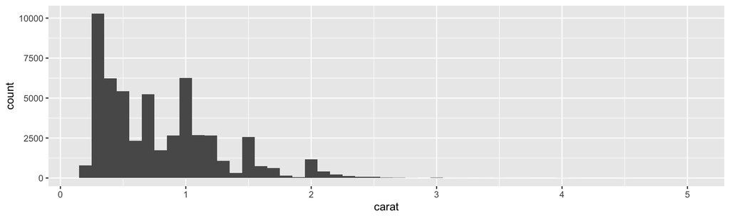

```r
histogram <- function(df, var, binwidth = NULL) {
  df |>
    ggplot(aes(x = {{ var }})) +
    geom_histogram(binwidth = binwidth)
}
diamonds |> histogram(carat, 0.1)
```

## You can still add layers

A plot function returns a ggplot object, so keep building with `+` (not `|>`):

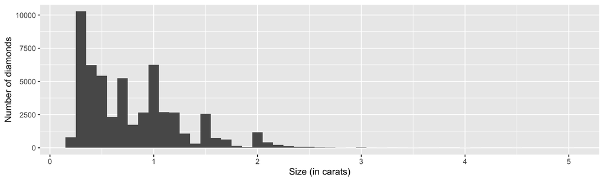

```r
diamonds |>
  histogram(carat, 0.1) +
  labs(x = "Size (in carats)", y = "Number of diamonds")
```

## More variables

Embrace each variable you pass to `aes()`:

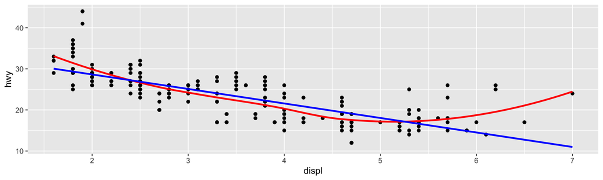

```r
linearity_check <- function(df, x, y) {
  df |>
    ggplot(aes(x = {{ x }}, y = {{ y }})) +
    geom_point() +
    geom_smooth(method = "loess", formula = y ~ x, color = "red", se = FALSE) +
    geom_smooth(method = "lm", formula = y ~ x, color = "blue", se = FALSE)
}
mpg |> linearity_check(displ, hwy)
```

## The walrus operator `:=`

To put an embraced name on the **left** of `=`, use `:=`:

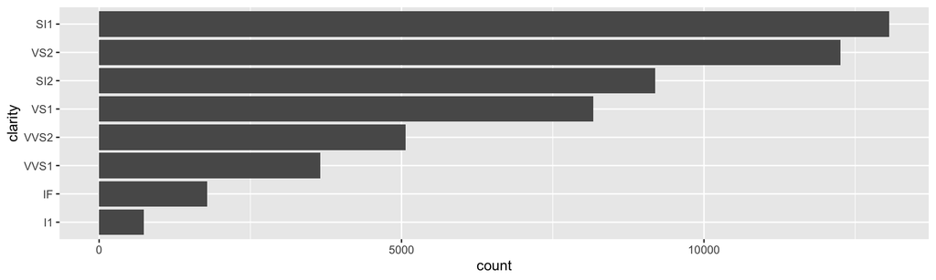

```r
sorted_bars <- function(df, var) {
  df |>
    mutate({{ var }} := fct_rev(fct_infreq({{ var }}))) |>
    ggplot(aes(y = {{ var }})) +
    geom_bar()
}
diamonds |> sorted_bars(clarity)
```

R’s syntax won’t allow `{ var } =`, so tidy evaluation uses `:=` to mean the same thing.

## Labeling with the variable name

`rlang::englue()` works like `str_glue()` but also understands `{ }`, inserting the variable’s *name* into a string:

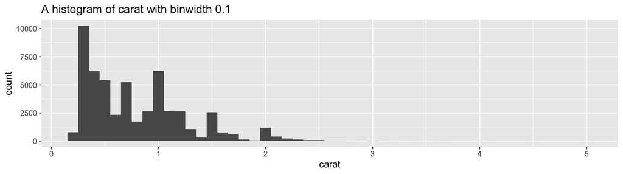

```r
histogram <- function(df, var, binwidth) {
  label <- rlang::englue("A histogram of {{var}} with binwidth {binwidth}")
  df |>
    ggplot(aes(x = {{ var }})) +
    geom_histogram(binwidth = binwidth) +
    labs(title = label)
}
diamonds |> histogram(carat, 0.1)
```

# Naming & style

## Names are for humans

R doesn’t care what you name things, but smart naming makes our lives easier.

- Function names should be **verbs**; arguments should be **nouns**.
  - exceptions: well-known nouns (`mean()`), or accessors (`coef()`).
- Prefer **clear over short** since autocomplete can type the long name for you.

```r
f()                      # too short, meaningless
my_awesome_function()    # not a verb, not descriptive
impute_missing()         # long but clear
collapse_years()         # long but clear
```

## Whitespace conventions

- `function(...)` is always followed by `{ }`.
- The body is indented **two extra spaces**.
- Put spaces inside `{ }` so the embracing stands out.

```r
# good
density <- function(color, facets, binwidth = 0.1) {
  diamonds |>
    ggplot(aes(x = carat, y = after_stat(density), color = {{ color }})) +
    geom_freqpoly(binwidth = binwidth) +
    facet_wrap(vars({{ facets }}))
}
```

Skimming the left-hand margin should reveal the structure of your code.

# Activity

## In-class activity

Open `day20-activity.R` in RStudio and work through the parts in order.

- **Part 1**: write & test **vector functions** (`rescale01`, a mutate helper, a summary helper).
- **Part 2**: write **data frame functions** using embracing `{ }` on `nycflights13`.
- **Part 3 (challenge)**: write a **plot function**, use `:=`, and label it with `rlang::englue()`.

Activity file

## Wrap-up & looking ahead

**What we covered**

- Write a function once you’ve copy-pasted **more than twice**
- **Vector functions**: same-length-out (mutate) vs single-value-out (summary)
- Always **test on known inputs**; improve in **one place**
- **Data frame functions**: embrace data-masking args with `{ }`
- `pick()` for tidy-selection inside data-masking; `:=` for names
- **Plot functions**: embrace inside `aes()`; label with `rlang::englue()`
- Names are **verbs**, clear beats short

**Upcoming**

- **Tue Jun 16:** control flow: `if/else`, `for`, `while`
- **Reading before Tue:** *R4DS* §26.1–26.3

**Reach out**

Stuck? Office hours, or email me (cgc5478@psu.edu) or Xinyue (xpw5228@psu.edu).

**Reference**

Syllabus · AI policy · Schedule · [*R4DS* Ch. 25](https://r4ds.hadley.nz/functions) · [tidyverse style guide](https://style.tidyverse.org/functions.html)